# Open-Source R development at Novo

Aksel Thomsen

CopenhagenR × 4R/um, 23 Oct 2026

## Speaker

**Aksel Thomsen**

Clinical Data Science Specialist @ Novo

Formerly at Statistics Denmark and Ferring Pharmaceuticals

*Economist turned R developer and clinical data scientist with a goal to make trial programming easier and more efficient.*

*Developer on several Open-Source packages including [{whirl}](https://novonordisk-opensource.github.io/whirl/), [{connector}](https://novonordisk-opensource.github.io/connector/) and [{mighty}](https://novonordisk-opensource.github.io/mighty/).*

akselthomsen

[akselthomsen](https://www.linkedin.com/in/akselthomsen/)

## Disclaimer

- All presenters are employees of Novo Nordisk A/S
- Views and opinions expressed are those of the presenters and not necessarily Novo Nordisk A/S
- Neither Novo Nordisk A/S nor the presenters have any financial interests in any of the software mentioned during the presentation

## Why Open-Source

## R in practice at Novo

- Used in clinical trials

```
%%{init: {'themeVariables': {'fontSize': '20px'}}}%%
flowchart LR
  A[("Raw data")] --> B[("Standardised<br>collected datasets")]
  B --> C[("Analysis<br>datasets")]
  C --> D["Tables &<br>figures"]
  D --> E["Reports &<br>documents"]
  E --> F("Regulators<br>(e.g. FDA)")
```

- 2023: Novo’s first R-based submission to the US FDA
- The FDA does not require any specific software for statistical analyses
- Regulated setting: every step must be documented and reproducible

## Why we develop in the open

**Same problems everywhere**  
Every pharma company builds the same tools; sharing avoids duplication ([pharmaverse](https://pharmaverse.org/))  
Compete on drugs, not code for reporting

**Better quality**  
More users find bugs and edge cases sooner; public code invites review

**Shared standards and workflows**  
[OpenStudyBuilder](https://www.openstudybuilder.com/): since May 2026 jointly maintained by Novo, Bayer and Boehringer Ingelheim

**Giving back & talent**  
We build on CRAN, the tidyverse and pharmaverse; working in the open makes our R work visible

[GitHub org](https://github.com/novonordisk-opensource) since 2023 · 77 public repos · 9 packages on CRAN

## Our packages

## Our packages at a glance

[figure not shown]

*Our goal is to provide tools to analyse data from clinical trials, and facilitate the entire trial conduct process, from data collection to reporting of clinical results.*  
[novonordisk-opensource.github.io/R-packages](https://novonordisk-opensource.github.io/R-packages/)

## {whirl} and {connector}

[figure not shown]

**Can you show what ran, when, and with which package versions?**

Runs R and Python scripts and writes an HTML log per script

[figure not shown]

**Where is the data, and how do I read it?**

One interface to files, databases, Databricks and SharePoint, configured in one YAML file

Built for clinical trials — useful anywhere you run R in production

Both are part of [pharmaverse](https://pharmaverse.org/)

## {whirl}

`_whirl.yml`

```yaml
steps:
  - name: "Create SDTM"
    paths:
      - "scripts/create_sdtm.R"
  - name: "Summary"
    paths:
      - "scripts/summary.R"
```

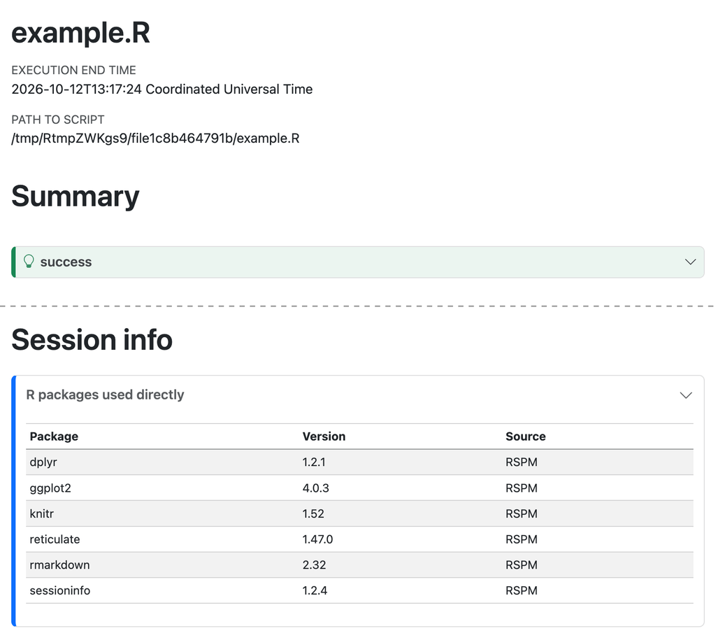

One HTML log per script, plus a summary · [Example log](https://novonordisk-opensource.github.io/whirl/articles/example_log.html)

```r
library(whirl)
run("_whirl.yml", n_workers = 2)
```

```
══ Executing scripts and generating logs ═══════════════════
```

```
→ Executing scripts in parallel using 2 worker(s)
```

```
The following steps will be executed
• Create SDTM
• Summary

── Create SDTM ─────────────────────────────────────────────

✔ create_sdtm.R: Completed succesfully. See log html.

── Summary ─────────────────────────────────────────────────

✔ summary.R: Completed succesfully. See log html.

══ End of process ══════════════════════════════════════════
```

## {connector}

`_connector.yml`

```yaml
datasources:
  - name: "sdtm"
    backend:
      type: "connector::connector_dbi"
      drv: "RSQLite::SQLite()"
      dbname: "data/sdtm.sqlite"
  - name: "adam"
    backend:
      type: "connector::connector_fs"
      path: "data/adam"
```

```r
library(connector)
cnt <- connect("_connector.yml")

cnt$sdtm$list_content_cnt()
## [1] "dm"
dm <- cnt$sdtm$read_cnt("dm")
cnt$adam$write_cnt(dm, "dm.parquet")
cnt$adam$list_content_cnt()
## [1] "dm.parquet"
cnt$adam$read_cnt("dm.parquet")
## # A tibble: 306 × 28
##   STUDYID      DOMAIN USUBJID  SUBJID RFSTDTC RFENDTC RFXSTDTC
##   <chr>        <chr>  <chr>    <chr>  <chr>   <chr>   <chr>
## 1 CDISCPILOT01 DM     01-701-… 1015   2014-0… 2014-0… 2014-01…
## 2 CDISCPILOT01 DM     01-701-… 1023   2012-0… 2012-0… 2012-08…
## 3 CDISCPILOT01 DM     01-701-… 1028   2013-0… 2014-0… 2013-07…
## 4 CDISCPILOT01 DM     01-701-… 1033   2014-0… 2014-0… 2014-03…
## 5 CDISCPILOT01 DM     01-701-… 1034   2014-0… 2014-1… 2014-07…
## # ℹ 301 more rows
## # ℹ 21 more variables: RFXENDTC <chr>, RFICDTC <chr>,
## #   RFPENDTC <chr>, DTHDTC <chr>, DTHFL <chr>, SITEID <chr>,
## #   BRTHDTC <chr>, AGE <dbl>, …
```

Extensions: {connector.databricks}, {connector.sharepoint} — same verbs, new backends

## {mighty}

## From trial data to analysis datasets

```
%%{init: {'themeVariables': {'fontSize': '22px'}}}%%
flowchart LR
  S[("Collected data<br>(SDTM)")] --> R["Hand-written<br>R code"]
  R --> A[("Analysis datasets<br>(ADaM)")]
  X[/"Specification<br>(Excel)"/] -. "must match" .-> R
  X --> D>"Documentation<br>for regulators"]
```

- **SDTM**: standard format for the collected trial data
- **ADaM**: standard for analysis-ready datasets, e.g. one row per patient
- Regulators expect the datasets *and* documentation of how every column is derived

**Today:** two sources of truth that drift apart, and every new study costs about the same as the last

## Declare what, not how

Specification `adsl.yml` (excerpt)

```yaml
id: ADSL
label: Subject Level Analysis Dataset
class: SUBJECT LEVEL ANALYSIS DATASET
structure: One record per subject
keys: [STUDYID, USUBJID]
# ...
columns:
  - id: STUDYID
  - id: USUBJID
  - id: ARM
  - id: AGE
  - id: AGEGR1
    component:
      id: age_group.mustache
      with:
        domain: ADSL
        variable: AGEGR1
```

Component `age_group.mustache`

```r
#' @title Age group
#' @description Age cut into the groups < 18, 18-64, 65-74 and >= 75 years
#' @param domain `character` Name of domain
#' @param variable `character` Name of new variable
#' @type column
#' @origin Derived
#' @method Age cut into the groups < 18, 18-64, 65-74 and >= 75 years.
#' @depends {{{domain}}} AGE
#' @outputs {{{variable}}}
#' @code
{{{domain}}} <- {{{domain}}} |>
  dplyr::mutate(
    {{{variable}}} = cut(
      AGE,
      breaks = c(-Inf, 18, 65, 75, Inf),
      labels = c("< 18 years", "18 - 64 years", "65 - 74 years", ">= 75 years"),
      right = FALSE
    )
  )
```

A component is a mustache template that declares what it needs and what it creates

## Render a component

```r
mighty.component::get_rendered_component(
  "age_group",
  params = list(domain = "ADSL", variable = "AGEGR1"),
  repos = "components"
)
```

```
<mighty_component_rendered/mighty_component/R6>
age_group: Age group
Type: column
Depends:
• ADSL.AGE
Outputs:
• AGEGR1
Code:
ADSL <- ADSL |>
  dplyr::mutate(
    AGEGR1 = cut(
      AGE,
      breaks = c(-Inf, 18, 65, 75, Inf),
      labels = c("< 18 years", "18 - 64 years", "65 - 74 years", ">= 75 years"),
      right = FALSE
    )
  )
```

Placeholders are filled from the specification’s `with:` block

## {mighty} writes the program

```r
results <- mighty::generate_adam_code(
  adam_specifications = "specs",
  path_connector_config = "_connector.yml"
)
```

Generated program (excerpt)

```r
# ADSL-1-read_data -------------------------------------------------------------
cnt <- connector::connect(config = "_connector.yml")
  DM <- cnt$sdtm$read_cnt(tolower('DM')) |>
  dplyr::select(AGE,ARM,STUDYID,USUBJID)
# ...
# ADSL-AGEGR1 ------------------------------------------------------------------
ADSL <- ADSL |>
  dplyr::mutate(
    AGEGR1 = cut(
      AGE,
      breaks = c(-Inf, 18, 65, 75, Inf),
      labels = c("< 18 years", "18 - 64 years", "65 - 74 years", ">= 75 years"),
      right = FALSE
    )
  )
# ...
# Save ADaM table
cnt$adam$write_cnt(ADSL, tolower("ADSL.parquet"), overwrite = TRUE)
```

- Builds a dependency graph of the steps and orders them
- Errors on missing inputs or cycles
- Output is plain, readable R, not a black box
- Data access via {connector}; run and log with {whirl}

## The mighty ecosystem

```
%%{init: {'themeVariables': {'fontSize': '20px'}}}%%
flowchart LR
  Y[/"YAML specs"/] --> M("{mighty.metadata}<br/>load + validate")
  S[("{mighty.standards}<br/>standard components")] --> C("{mighty.component}<br/>fetch + render")
  U[/"custom components"/] --> C
  M --> G("{mighty}<br/>dependency graph<br/>and orchestrator")
  C --> G
  G --> P["R programs"] --> D[("ADaM datasets")]
```

- {mighty.metadata}: on CRAN (0.1.0)
- {mighty}, {mighty.component}: in development, preparing for CRAN
- {mighty.standards}: first standard components in progress
- Planned: toolbox (define.xml documentation), editor, AI assistant

Feedback and issues welcome  
novonordisk-opensource/mighty

## Thank you

Questions and discussion

GitHub: github.com/novonordisk-opensource

Package overview: [novonordisk-opensource.github.io/R-packages](https://novonordisk-opensource.github.io/R-packages/)

r-universe: novonordisk-opensource.r-universe.dev

pharmaverse: [pharmaverse.org](https://pharmaverse.org/)